# Introduction to treemut

### Overview

Code implementing maximum likelihood assignment of mutations to trees. The method uses an EM method to soft assign mutations to branches and simultaneously estimate branch lengths.

### Algorithm

Each mutation is assigned to branch with probability:

P(Mutation has genotype ) ~ P(Read Count | genotype)P(genotype)

Where a given branch implies a genotype and P(genotype) is proportional to branch length. The read counts are modelled using the binomial distribution with up to 4 distinct per sample specific error rates and an assumed VAF=0.5 for variant sites and VAF=0 for wild type sites.

## Installation

```r
library(devtools)
install_git("https://github.com/nangalialab/treemut")
```

## Example usage

### Generate tree

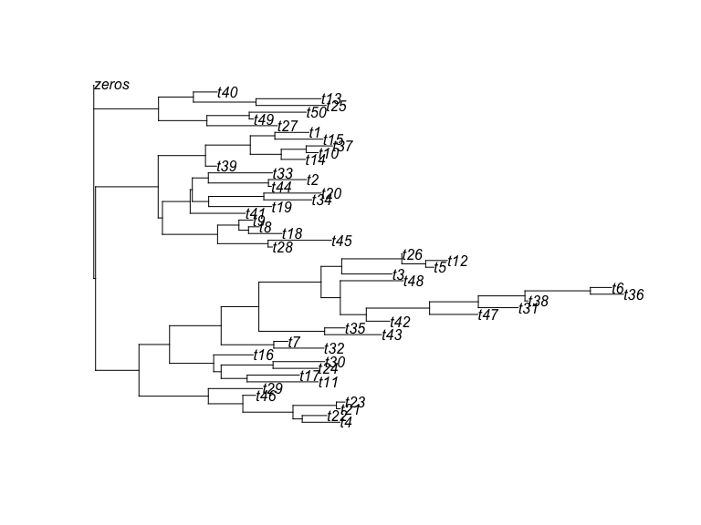

```r
tree=generate_random_tree(50)
plot(tree)
```

Note that the tree includes an outgroup “zeros”. This can be added to a tree obtained from other sources by

```r
tree=bind.tree(tree,read.tree(text="(zeros:0);"))
```

Now we create a summary object that summarises each branch of the tree as a genotype (1’s for samples that share the branch and 0’s for the rest). This just requires the APE tree as input:

```r
  df=reconstruct_genotype_summary(tree)
cat(df$samples,"\n")
```

```
## t4 t22 t21 t23 t46 t29 t11 t17 t24 t30 t16 t32 t7 t43 t35 t42 t47 t31 t38 t36 t6 t48 t3 t5 t12 t26 t28 t45 t18 t8 t9 t41 t19 t34 t20 t44 t2 t33 t39 t14 t10 t37 t15 t1 t27 t49 t50 t25 t13 t40 zeros
```

```r
head(df$df[, 1:3])
```

```
##                                               profile edge_length mut_count
## 1 111111111111111111111111111111111111111111110000000           5        44
## 2 111111111111111111111111110000000000000000000000000         122        26
## 3 111111000000000000000000000000000000000000000000000         195         6
## 4 111110000000000000000000000000000000000000000000000          97         5
## 5 111100000000000000000000000000000000000000000000000         141         4
## 6 110000000000000000000000000000000000000000000000000          26         2
```

Where

- “profile” column indicates the genotype (in the same order as df sample)
- “edge_length” gives the branch edge length i.e. number of mutations assigned to branch (perfectly known here)
- “mut_count” Indicates the number of mutant samples implied by the genotype (i.e. the number of 1s in “profile”)

We now simulate some data based on the tree:

```r
 simdat=simulate_reads_from_tree(df,12)
head(simdat$mtr)
```

```
##      t4 t22 t21 t23 t46 t29 t11 t17 t24 t30 t16 t32 t7 t43 t35 t42 t47 t31 t38
## [1,]  3   7   7   1   7   4   6   8   4   5   5   7  8  11   4  10  10   7   9
## [2,]  4   2   6   6   6   8   9   8   7   7   5   6  3  10   9   7   3   3   8
## [3,]  4   7   8   3   3   5   3   5   5   6   3   7  9   5   2   4   5  10   8
## [4,]  8   5   6   7   8   8   2   5   8   4   3   8 10   6   3   7   7   3   4
## [5,]  7   9   8  13   9   9   8   5   3   8   8   6  7   5   4   5   2  10   7
## [6,]  5  11   7   7   9   9   3   5   6   6   4   6  6   6   7   8   5   7   5
##      t36 t6 t48 t3 t5 t12 t26 t28 t45 t18 t8 t9 t41 t19 t34 t20 t44 t2 t33 t39
## [1,]   3  3   7  4  6   5   6   4   7   2  6  8   6   7   9   5   9  5   5   5
## [2,]   9  2   4  8  5   5   5   6   7   4  4  6   6   7   2   9   7  5  13   6
## [3,]   4  7  12  9  7   2   9   3   8   8  7  6   6   2   4   7   8  3   6   7
## [4,]   6  4  15  7  6   9   6   4   1   5  4  5   7  11   3   6   4  7   4   4
## [5,]   2  7  11  8  7   3   4   6   6   6  5  5   5   6   5   1   5  6   8   3
## [6,]   2  7   8  9  6   5   7   0   0   0  0  0   0   0   0   0   0  0   0   1
##      t14 t10 t37 t15 t1 t27 t49 t50 t25 t13 t40 zeros
## [1,]   5   9   5   9  3   0   0   0   1   0   0     0
## [2,]   5   8   6   4  9   0   0   1   0   0   0     0
## [3,]   5   5   5   3  6   0   0   0   0   0   0     0
## [4,]   4   5   6   1  7   0   0   1   1   0   0     0
## [5,]   3   6   9   5  5   0   0   0   0   0   0     0
## [6,]   0   0   0   0  0   0   0   0   0   0   1     0
```

```r
head(simdat$depth)
```

```
##      t4 t22 t21 t23 t46 t29 t11 t17 t24 t30 t16 t32 t7 t43 t35 t42 t47 t31 t38
## [1,] 10  10  12   5  15  12  20  17   8  10  11  14 20  14  12  18  11  17  17
## [2,] 11  13  11   9  12  13  17  11  11  14  11  10  7  14  14  11   7   8  15
## [3,]  9  10  15  12  10  11  10  15  12  12  16  12 13   9   8   9  12  17  14
## [4,] 14  12  12  11  14  16  10  10  19   8   8  14 13  11   5  16  12  10   7
## [5,] 18  11  17  20  15  14  14  11  11  13  15  15 16   9   8  13   5  17  12
## [6,] 16  16  17   9  15  17   8  10  14  12  10  15 15  12  10  13  13  12  12
##      t36 t6 t48 t3 t5 t12 t26 t28 t45 t18 t8 t9 t41 t19 t34 t20 t44 t2 t33 t39
## [1,]   9  7  11  9 11   7  12   9  14   9 12 19  11  18  12   9  13  9  10   8
## [2,]  15  6  16 13 11   9  15   9  16   6  7 12  13  12   9  15  11 12  16   9
## [3,]  18 16  18 12  9   8  12   7  12  14 15  8  13   9   9  12  11  6  17  12
## [4,]  12  6  18 13 15  14  15  11   5  15  7  9  14  17  10   9  11 12  11   7
## [5,]   6  9  17 13 14   8  10  12  11  14 12 12  12  16  10   3  15 14  17   6
## [6,]   4  9  12 16 11  13  15  11  11  15 14 14   8   6  13  15  15 12  11   9
##      t14 t10 t37 t15 t1 t27 t49 t50 t25 t13 t40 zeros
## [1,]  10  15   8  17  9  14  11  10  13   9  10   100
## [2,]  17  16  10   9 17  18  16   8  12  11  15   100
## [3,]  12   8   9  10 10  10  24  15  11  14  16   100
## [4,]  10   9  12   5 10   9  17  12  16  14   6   100
## [5,]   9  10  13  12 10  10  11  14  10  12  13   100
## [6,]  18  16   8  18 17  14   9   6  14  18  15   100
```

```r
print(simdat$p.error)
```

```
##  [1] 1e-02 1e-02 1e-02 1e-02 1e-02 1e-02 1e-02 1e-02 1e-02 1e-02 1e-02 1e-02
## [13] 1e-02 1e-02 1e-02 1e-02 1e-02 1e-02 1e-02 1e-02 1e-02 1e-02 1e-02 1e-02
## [25] 1e-02 1e-02 1e-02 1e-02 1e-02 1e-02 1e-02 1e-02 1e-02 1e-02 1e-02 1e-02
## [37] 1e-02 1e-02 1e-02 1e-02 1e-02 1e-02 1e-02 1e-02 1e-02 1e-02 1e-02 1e-02
## [49] 1e-02 1e-02 1e-06
```

We now have required information: mutant read matrix “mtr”, depth matrix “depth”, genotype summary “df”,and base calling error rate “p.error” - note how we’ve set the last entry corresponding to “zeros” outgroup very low.

```r
 res=assign_to_tree(tree,simdat$mtr,simdat$depth,error_rate=simdat$p.error)
```

```
## Initialising edge lengths to 1
## delta edge length= 0.9904631
## Loglik= -612980
## delta edge length= 0.009564176
## Loglik= -563868.6
## delta edge length= 0.0004393621
## Loglik= -563865.7
## delta edge length= 2.919124e-05
## Loglik= -563865.7
## delta edge length= 2.323098e-06
## Loglik= -563865.7
## Finished assigning mutations
## calculating pvalues
## On 1000  of  10171
## On 2000  of  10171
## On 3000  of  10171
## On 4000  of  10171
## On 5000  of  10171
## On 6000  of  10171
## On 7000  of  10171
## On 8000  of  10171
## On 9000  of  10171
## On 10000  of  10171
```

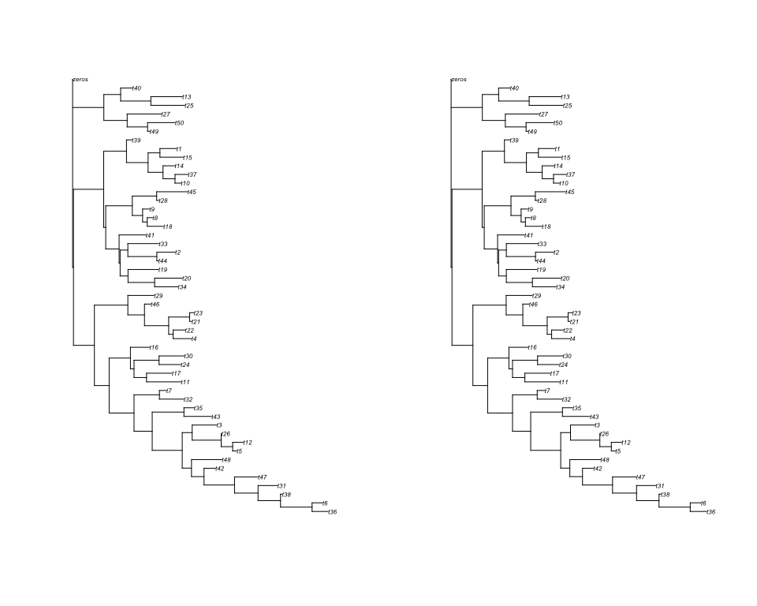

```r
tree_estimated=res$tree
par(mfcol=c(1,2))
plot(ladderize(tree,right=TRUE),cex=0.5)
plot(ladderize(tree_estimated,right=TRUE),cex=0.5)
```

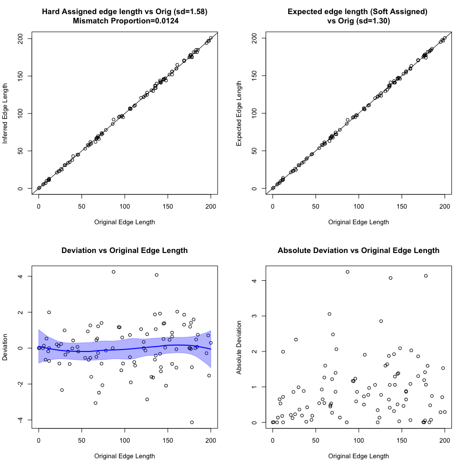

```r
sim=list(edge_length_orig=df$df$edge_length,
         edge_length_inferred=res$df$df$edge_length,
         expected_edge_length_inferred=res$df$df$expected_edge_length,
         edge_idx_orig=simdat$edge,
         edge_idx_ml=res$summary$edge_ml)
plot_sim_result(sim)
```

## Specifying an alternative VAF

This is most relevant when the samples are perhaps sub-clonal or non-pure and therefore consistently exhibit a VAF<0.5 and also the VAF=1 setting is appropriate to single copy sex chromosomes.

We use a simple error model to give the binomial probability of observing a mutant base for a given VAF:

$$p(\text{base called mutant}|
Vaf=V)=p(\text{base called mutant}| \text{base is mutant})V+p(\text{base
called mutant}| \text{base is wild type})(1-V)$$

where
$$p(\text{base called mutant}|
\text{base mutant})=1-\epsilon$$

and
$$p(\text{base called mutant}|
\text{base is wild type})=\epsilon$$

Giving

$$p(\text{base called mutant}| Vaf=V)=
V(1-2\epsilon)+\epsilon$$

Note that this differs from version 1.1 where the depth matrix was assumed to be mutant + all other reads.

### Illustrative simulations showing the consequence of mis-specification of VAF on branch length estimation

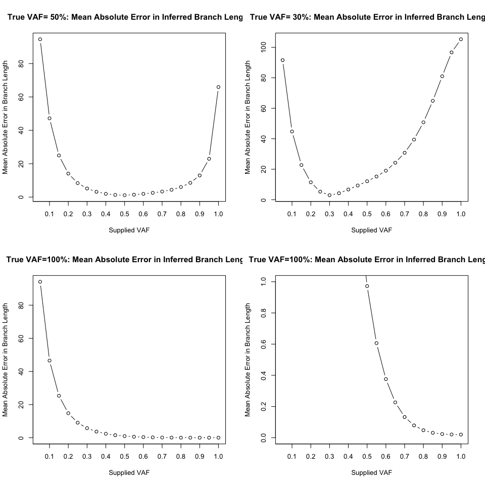

```r
par(mfrow=c(2,2))
for(vaf in c(0.5,0.3,1)){
  xval=seq(0.05,1,0.05)
  simdat=simulate_reads_from_tree(df,12,vaf = vaf)
  sims=sapply(xval,function(v) {res=assign_to_tree(tree,simdat$mtr,simdat$depth,error_rate=simdat$p.error,vaf=v,bverbose=FALSE);treemut:::compare_sim(df,res)})
  plot(xval,sims["adsoft",],type="b",xaxt="n",xlab="Supplied VAF",
       main=sprintf("True VAF=%3.0f%%: Mean Absolute Error in Inferred Branch Length",100*vaf),ylab="Mean Absolute Error in Branch Length")
  axis(1,at=seq(0,1,0.1))
  if(vaf==1){
    plot(xval,sims["adsoft",],type="b",xaxt="n",xlab="Supplied VAF",main=sprintf("True VAF=%3.0f%%: Mean Absolute Error in Inferred Branch Length",100*vaf),
         ylab="Mean Absolute Error in Branch Length",ylim=c(0,1))
    axis(1,at=seq(0,1,0.1))
  }
}
```